# Sensitivity analysis model parameters noLight

Daniel Gschwentner

2024-07-02

## Note for Carly

I changed the code to show differences as percent instead of relative ratios. I’ve subtracted 100% from each simulation to normalize/show the percent different (i.e. a value below 0% means decrease relative to baseline, a value >0% means an increase). You’ll notice that the % change is quite large for a few parameters (e.g. >1000% increase relative to baseline). I think this messes with the visualization as the color scale becomes misleading: basically, it is impossible to discern small changes because the larger values stretch the color palette. We can probably fix this with some clever coding of the color scheme (e.g. use a categorical color scheme) but I thought the relative changes helped circumvent this issue.

### Notes

Somehow everything revolves around N:P of 16 even when using average phytoplankton stoichiometry… there seem to be shifts in sensitivity depending on whether N or P limitation prevails.

Much greater changes to baseline in Michaelis-Menten model compared to Droop model –> luxury uptake allows for decoupling of growth and resource supply –> makes model less sensitive? provides buffering capacity?!

## Overview

Code to perform sensitivity analysis of algal physiology parameters for Michaelis-Menten and Droop models.

## Setup

For the models I am using the average parameter values from the table below. These parameters are from [Edwards et al., 2016](https://figshare.com/articles/dataset/Data_Paper_Data_Paper/3562857?file=5635515).

```
## ──────────────────────────────────────────────────────── Delimiter: "," chr
## (1): Trait dbl (5): ...1, diatoms, greens, cyanos, average
```

Trait parameters

| Trait | diatoms | greens | cyanos | average |
| --- | --- | --- | --- | --- |
| K_N_mgL | 0.064 | 0.036 | 0.033 | 0.0500 |
| K_P_mgL | 0.005 | 0.028 | 0.026 | 0.0165 |
| Qmax_mg_N_mg_C | 0.201 | 0.068 | 0.023 | 0.1345 |
| Qmax_mg_P_mg_C | 0.146 | 0.015 | 0.008 | 0.0805 |
| Qmin_mg_N_mg_C | 0.155 | 0.025 | 0.010 | 0.0900 |
| Qmin_mg_P_mg_C | 0.020 | 0.001 | 0.001 | 0.0105 |
| Vmax_mg_N_mg_C | 4.490 | 0.416 | 0.034 | 2.4530 |
| Vmax_mg_P_mg_C | 0.608 | 0.243 | 0.113 | 0.4255 |
| umax_N | 0.860 | 1.320 | 0.860 | 1.0900 |
| umax_P | 0.610 | 0.630 | 0.655 | 0.6200 |
| K_light | 167.800 | 165.250 | 88.600 | 166.5250 |
| umax | 0.455 | 0.875 | 0.640 | 0.6650 |

### Model setup

## Run baseline models

### Michaelis Menten model

### Droop models

## Sensitivity analysis

### Michaelis-Menten models

Increase and decrease algal physiology parameters by +/-10% and store the output. Calculate the change relative to baseline conditions across TN and TP loads.

Code chunk below varies parameters by +10%

Code chunk below varies parameters by -10%  
(there is probably a more elegant way to do this but this simple approach works for now.

The code chunk below re-formats the data and merges the simulations with the baseline runs. I’ve calculated the relative change from the simulation to the baseline for a given TN and TP load as

$$\Delta_{biomass\%} = \frac{sensitivity_i * 100\%}{baseline}$$

where $\Delta_{biomass}$ is the relative change in biomass, baseline is the baseline biomass, and sensitivity<sub>i</sub> is the biomass for a given parameter in the sensitivity analysis.

In addition, I calculated which parameter results in the maximum change in biomass relative to the baseline. It is important to note that this doesn’t tell us the direction of change just the magnitude of change.

### Droop models

Increase and decrease algal physiology parameters by +/-10% and store the output. Calculate the change relative to baseline conditions across TN and TP loads.

The code chunk below re-formats the data and merges the simulations with the baseline runs. I’ve calculated the relative change from the simulation to the baseline for a given TN and TP load as

$$\Delta_{biomass\%} =
\frac{sensitivity_i * 100%}{baseline}$$

where $\Delta_{biomass}$ is the relative change in biomass, baseline is the baseline biomass, and sensitivity<sub>i</sub> is the biomass for a given parameter in the sensitivity analysis.

In addition, I calculated which parameter results in the maximum change in biomass relative to the baseline. It is important to note that this doesn’t tell us the direction of change just the magnitude of change.

## Summary

### Michaelis-Menten

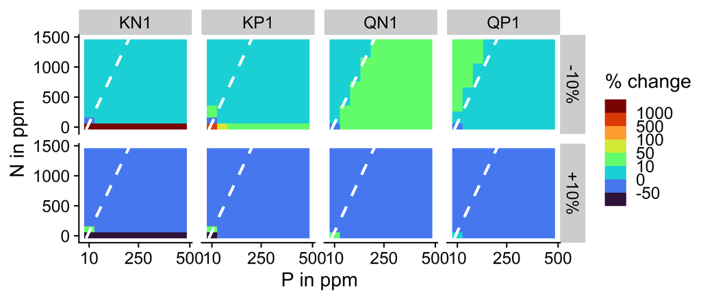

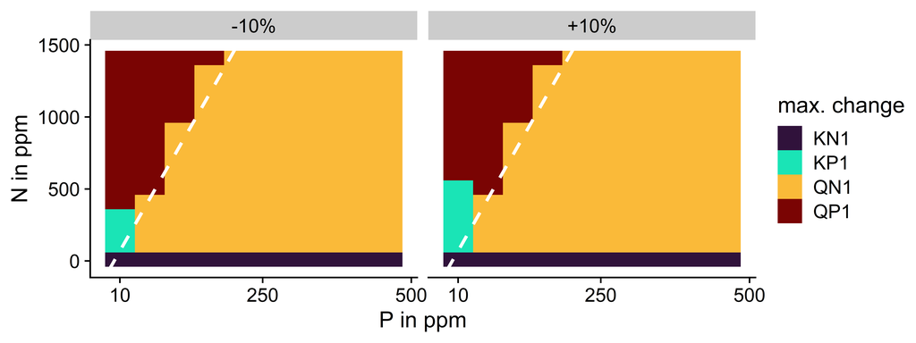

#### Conclusion for Michaelis-Menten models

### Droop models

#### Algal biomass

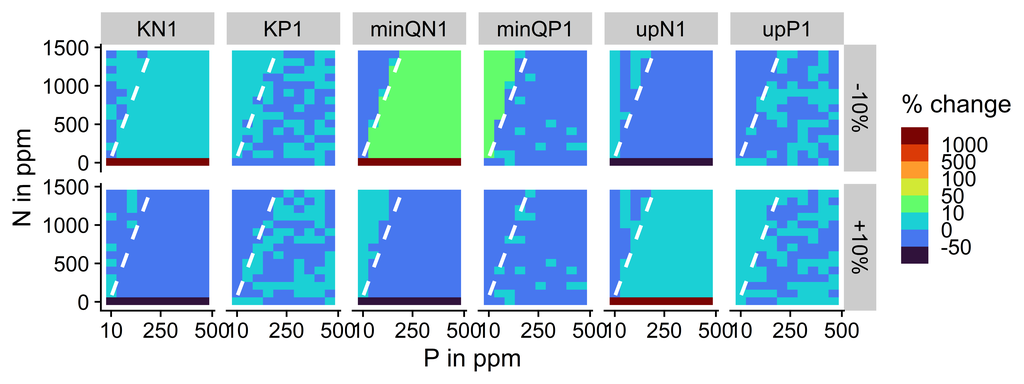

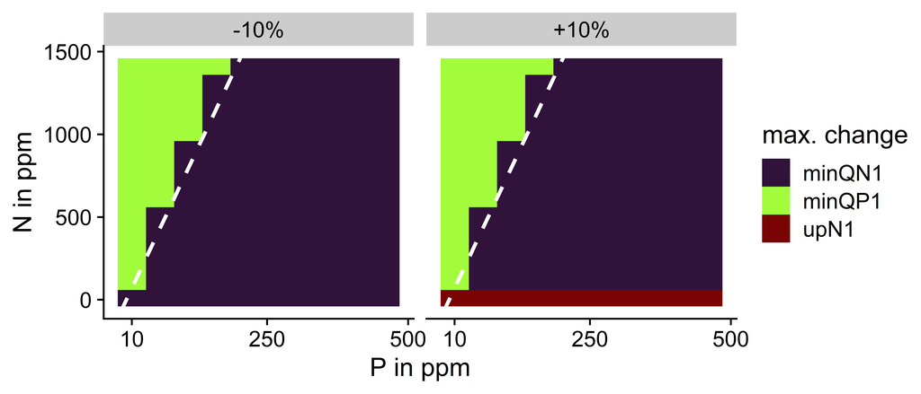

#### Cellular P content

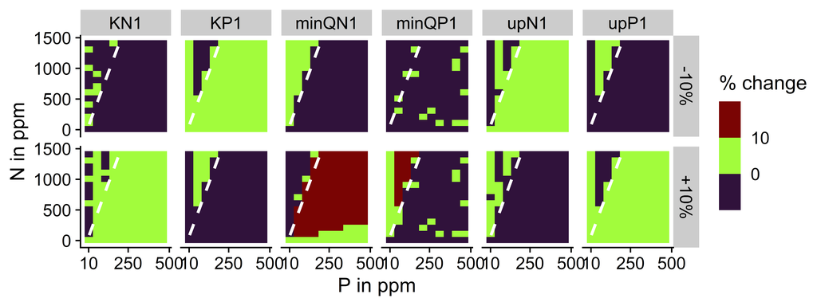

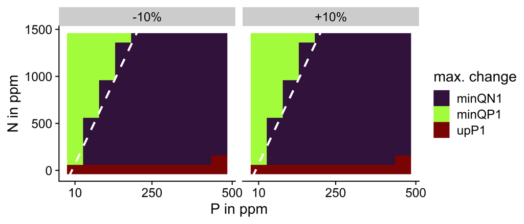

#### Cellular N

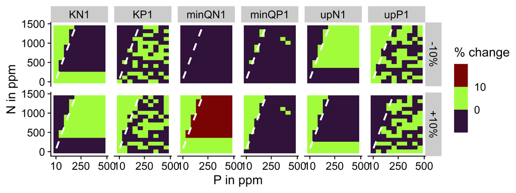

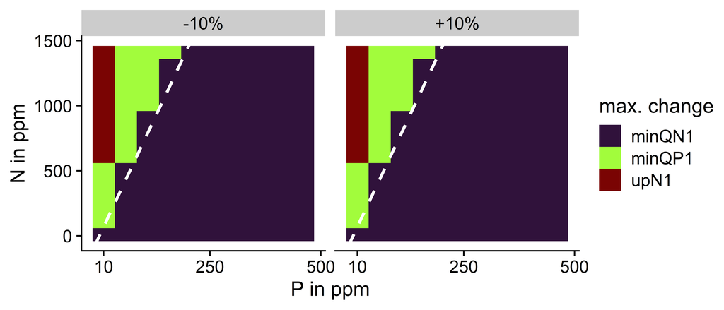